# earthquake Package

Kevin Sykora

2017-10-13

This package processes and visualizes NOAA earthquake data.

The package cleans and tidy’s the data, creates static timeline plots, and creates dynamic leaflet plots.

Before we begin, let’s load in an R dataset:

```r
library(earthquake)
library(dplyr)
library(ggplot2)
library(grid)
data(earthquake_raw)
```

earthquake_raw is a data.frame that holds the raw NOAA data.

## Clean the data

The NOAA datasets do not come by default in a clean format. The earthquake package includes tools for cleaning data.

One of the tools is the `eq_clean_data` function:

```r
earthquake_clean <- earthquake_raw %>% earthquake::eq_clean_data()
head(earthquake_clean[["DATE"]])
```

```
## [1] "0010-01-01" "0011-01-01" "0017-01-01" "0023-01-01" "0025-01-01"
## [6] "0027-01-01"
```

Many common R date functions do not support BCE dates. Most earthquake analysis focuses on more recent events. Therefore we drop BCE dates to maintain user flexibility.

The `eq_clean_data` creates a date column, removes NA columns and drops BCE dates.

Another tool is the `eq_location_clean` function:

```r
earthquake_clean_loc <- earthquake_raw %>% earthquake::eq_location_clean()
#Original Location Name
head(earthquake_raw[["LOCATION_NAME"]])
```

```
## [1] "JORDAN:  BAB-A-DARAA,AL-KARAK"     "TURKMENISTAN:  W"
## [3] "SYRIA:  UGARIT"                    "GREECE:  THERA ISLAND (SANTORINI)"
## [5] "ISRAEL:  ARIHA (JERICHO)"          "ITALY:  LACUS CIMINI"
```

```r
#Cleaned Location Name
head(earthquake_clean_loc[["LOCATION_NAME"]])
```

```
## [1] "Bab-A-Daraa,Al-Karak"     "W"
## [3] "Ugarit"                   "Thera Island (Santorini)"
## [5] "Ariha (Jericho)"          "Lacus Cimini"
```

The `eq_location_clean` cleans up the location name for future annotations.

## Create timeline plots

The earthquake package also includes new geoms for plotting timelines.

The `geom_timeline` creates timeline plots of the cleaned NOAA data:

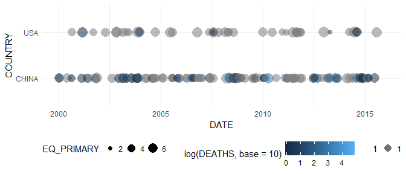

```r
ggplot(data=earthquake_clean %>%
         filter(COUNTRY %in% c("CHINA", "USA") ))+
  geom_timeline(aes(x = DATE, color = log(DEATHS, base = 10), y = COUNTRY,
                    alpha = 1, xmin=as.Date("2000-01-01"), xmax=as.Date("2015-12-31"), size = EQ_PRIMARY)) +
  scale_color_continuous()+
  theme_minimal()+theme(legend.position = "bottom")
```

You can add in the `geom_timelinelabel` geom to make annotations. It has an additional parameter n_max. This only labels the highest n_max magnitude earthquakes.

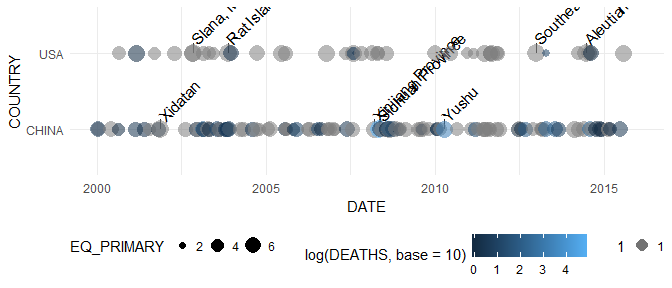

```r
ggplot(data=earthquake_clean %>%
         filter(COUNTRY %in% c("CHINA", "USA") ))+
  geom_timelinelabel(aes(x = DATE, label= LOCATION_NAME, y = COUNTRY,
                         xmin=as.Date("2000-01-01"), xmax=as.Date("2015-12-31"), mag = EQ_PRIMARY), n_max = 4)+
  geom_timeline(aes(x = DATE, color = log(DEATHS, base = 10), y = COUNTRY,
                    alpha = 1, xmin=as.Date("2000-01-01"), xmax=as.Date("2015-12-31"), size = EQ_PRIMARY)) +
  scale_color_continuous()+
  theme_minimal()+theme(legend.position = "bottom")
```

## Leaflet Plots

The `eq_map` function takes in a cleaned NOAA earthquake dataset, and an annotation column. It outputs a leaflet plot with the earthquakes on a map and annotations (available by clicking on the point) that describe them.

```r
  earthquake_clean %>%
  dplyr::filter(COUNTRY == "MEXICO" & lubridate::year(DATE) >= 2000) %>%
  eq_map(annot_col = "DATE")
```

[interactive chart not shown]

The `eq_create_label` function assumes that the dataset has columns titled LOCATION_NAME, EQ_PRIMARY, and deaths that describe: the name of the location of the earthquake, the magnitude of the earthquake, and the number of deaths associated with the earthquake, respectively. It then creates an html tagged output for use in the `eq_map` annotations.

```r
  earthquake_clean %>%
  dplyr::filter(COUNTRY == "MEXICO" & lubridate::year(DATE) >= 2000) %>%
  dplyr::mutate(popup_text = eq_create_label(.)) %>%
  eq_map(annot_col = "popup_text")
```

[interactive chart not shown]

## Summary

The `earthquake` package contains functions for cleaning NOAA earthquake data, plotting timelines, and making leaflet plots. I hope you enjoy!